# 第１回 ガイダンス

応用計量経済学

佐藤 秀保

sato0035@toyo.jp

## 授業の問題意識

### 問題１

- データ分析に**統計学**は必須
- **統計学**には誤用が多い
  - 調査・分析方法の誤り
  - 結果の誤った解釈
  - 研究不正？

### 問題２

- 分析でよく直面する「**内生性**」問題
  - 因果関係を考える上で必須
  - 計量経済学が強い
- 知らないと；
  - 調査・分析方法の誤り
  - 結果の誤った解釈

## 目的

- 以下の能力の習得
  1. 統計学における誤用回避
  2. 計量経済学における内生性への対処
  3. 以上を踏まえた総合的な実践

## 内容

1. 第１～４回：統計学の誤用
2. 第５～８回：計量経済学における内生性問題
3. 第９～15回：データ分析実践

   （R/RStudioの利用を想定）

### スケジュール（当初案）

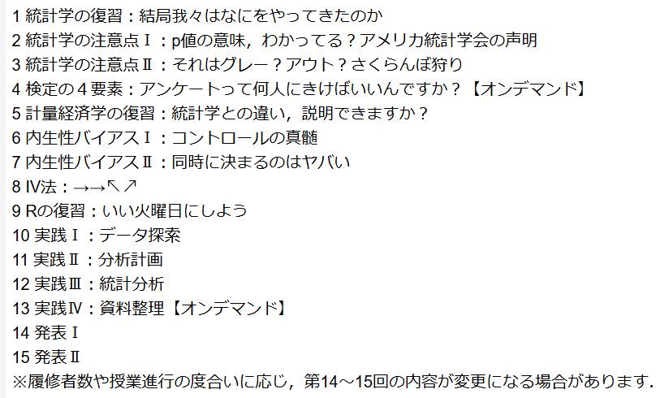

### スケジュール（現行案）

- 履修者数が多く，授業内での発表は困難
- 第14~15回「発表」を「実践・スライド作成」に
  - スライド提出でその内容を評価

### 持ち物

- ノートPC
  - 使用できない授業回もあるかもしれませんがご容赦を…
- メモできるもの
  - ノート/メモ帳/タブレット端末/ノートPC/スマフォ
  - 重要そう/忘れそうな点等を書き留める

## 成績

### 課題，試験，出席

- 課題：100%，試験なし
- 出席：15回中10回以上必要
  - [manaba出席管理オプション](https://www.ace.toyo.ac.jp/ct/page_8317332c618577)を使用
  - 成績算出の得点にはならない
  - オンデマンド時は課題提出で出席

### 東洋大学成績評価基準

| 合否 | 成績 | 評点範囲 |
| --- | --- | --- |
| 合格 | S | 100-90 |
| 合格 | A | 89-80 |
| 合格 | B | 79-70 |
| 合格 | C | 69-60 |
| 不合格 | D | 59-40 |
| 不合格 | E | 39-0 |
| 不合格 | * | 出席不足など |

## 質問

- ACEの「スレッド」へお気軽に
- 個人情報に関わる内容は，sato0035@toyo.jpまで